# Econ 320: Python Assignment 3

## Package setup

```python
# Import necessary packages here

import numpy as np
import pandas as pd
import matplotlib.pyplot as plt
import seaborn as sns
import  wooldridge as woo
import statsmodels.formula.api as smf
import scipy.stats as stats
from IPython.core.display import HTML
import statsmodels.formula.api as smf
import statsmodels.api as sm
from stargazer.stargazer import Stargazer
# Code to print path of current working directory
import os
print(os.getcwd())
```

```
/Users/jonatanpeguero/Econ 320 lab
```

# Question 1

The dataset *ps2q1.dta* contains data on 177 chief executive officers and can be used to examine the effects of firm performance on CEO salary.

i. Estimate a model relating the CEO's annual salary, the dependent variable, to firm sales, the independent variable.

$$salary_i= \beta_0 + \beta_1sales_i +u_i$$

What is your estimate of the intercept and the slope? Don't forget the units, which you can find using the "describe" command. Interpret these estimates, providing an intuitive description that a person who has not taken econometrics can understand. Does your result make economic sense?

```python
df = pd.read_stata('ps2q1.dta')
df.info()
df.describe()
```

```
<class 'pandas.core.frame.DataFrame'>
RangeIndex: 177 entries, 0 to 176
Data columns (total 12 columns):
 #   Column    Non-Null Count  Dtype
---  ------    --------------  -----
 0   salary    177 non-null    int16
 1   age       177 non-null    int8
 2   college   177 non-null    int8
 3   grad      177 non-null    int8
 4   comten    177 non-null    int8
 5   ceoten    177 non-null    int8
 6   sales     177 non-null    float32
 7   profits   177 non-null    int16
 8   mktval    177 non-null    float32
 9   comtensq  177 non-null    int16
 10  ceotensq  177 non-null    int16
 11  profmarg  177 non-null    float32
dtypes: float32(3), int16(4), int8(5)
memory usage: 4.5 KB
```

|  | salary | age | college | grad | comten | ceoten | sales | profits | mktval | comtensq | ceotensq | profmarg |
| --- | --- | --- | --- | --- | --- | --- | --- | --- | --- | --- | --- | --- |
| count | 177.000000 | 177.000000 | 177.000000 | 177.000000 | 177.000000 | 177.000000 | 177.000000 | 177.000000 | 177.000000 | 177.000000 | 177.000000 | 177.000000 |
| mean | 939.192090 | 56.429379 | 0.971751 | 0.531073 | 22.502825 | 7.954802 | 3529.463379 | 207.830508 | 3600.316406 | 656.683616 | 114.124294 | 6.420110 |
| std | 1211.342455 | 8.421890 | 0.166152 | 0.500449 | 12.294735 | 7.150826 | 6088.654297 | 404.454296 | 6442.275391 | 577.122655 | 212.565996 | 17.860743 |
| min | 100.000000 | 33.000000 | 0.000000 | 0.000000 | 2.000000 | 0.000000 | 29.000000 | -463.000000 | 387.000000 | 4.000000 | 0.000000 | -203.076920 |
| 25% | 471.000000 | 52.000000 | 1.000000 | 0.000000 | 12.000000 | 3.000000 | 561.000000 | 34.000000 | 644.000000 | 144.000000 | 9.000000 | 4.230769 |
| 50% | 707.000000 | 57.000000 | 1.000000 | 1.000000 | 23.000000 | 6.000000 | 1400.000000 | 63.000000 | 1200.000000 | 529.000000 | 36.000000 | 6.833713 |
| 75% | 1119.000000 | 62.000000 | 1.000000 | 1.000000 | 33.000000 | 11.000000 | 3500.000000 | 208.000000 | 3500.000000 | 1089.000000 | 121.000000 | 10.947369 |
| max | 15000.000000 | 86.000000 | 1.000000 | 1.000000 | 58.000000 | 37.000000 | 51300.000000 | 2700.000000 | 45400.000000 | 3364.000000 | 1369.000000 | 47.457626 |

```python
model1 = smf.ols(formula = 'salary ~ sales', data = df).fit()
model1.summary()
```

OLS Regression Results

| Dep. Variable: | salary | R-squared: | 0.438 |
| --- | --- | --- | --- |
| Model: | OLS | Adj. R-squared: | 0.435 |
| Method: | Least Squares | F-statistic: | 136.6 |
| Date: | Wed, 23 Oct 2024 | Prob (F-statistic): | 1.08e-23 |
| Time: | 16:31:24 | Log-Likelihood: | -1456.2 |
| No. Observations: | 177 | AIC: | 2916. |
| Df Residuals: | 175 | BIC: | 2923. |
| Df Model: | 1 |  |  |
| Covariance Type: | nonrobust |  |  |

|  | coef | std err | t | P>\|t\| | [0.025 | 0.975] |
| --- | --- | --- | --- | --- | --- | --- |
| Intercept | 474.2893 | 79.154 | 5.992 | 0.000 | 318.071 | 630.508 |
| sales | 0.1317 | 0.011 | 11.687 | 0.000 | 0.109 | 0.154 |

| Omnibus: | 187.510 | Durbin-Watson: | 2.086 |
| --- | --- | --- | --- |
| Prob(Omnibus): | 0.000 | Jarque-Bera (JB): | 8601.497 |
| Skew: | 3.774 | Prob(JB): | 0.00 |
| Kurtosis: | 36.307 | Cond. No. | 8.12e+03 |

Notes:  
[1] Standard Errors assume that the covariance matrix of the errors is correctly specified.  
[2] The condition number is large, 8.12e+03. This might indicate that there are  
strong multicollinearity or other numerical problems.

## i) The intercept for this model is 474.29, which means that when there aren't any sales, the average salary for those 177 chief executive officers is 474,290.00 USD. This makes sense because the chief executive officers can maybe have a base salary of that much, and then they are able to make more with bonuses or some other form of compensation. The coefficient for sales in this model is 0.1317, which means that for each additional sale that is made, the CEO's salary goes up by 131.70 USD. This makes sense for those CEO's that have an expensive product.

ii. Calculate the mean of $salary$ and $sales$. Use these values to prove that the predicted regression line estimated in regression (1) goes through the means of $salary$ and $sales$.

```python
# save predicted value of
salary_avg = df['salary'].mean()
sales_avg = df['sales'].mean()
print(f'The average salary is: {salary_avg:.3f}')
print(f'The average of the sales are:{sales_avg:.3f}')
#summary(model1)
intercept1 = model1.params['Intercept']
sales_coeff = model1.params['sales']
predic1 = intercept1 + sales_coeff * sales_avg
print(f'The predicted salary given these averages is: {predic1:.3f}')
```

[output not shown]

It appears as sales increase the marginal change to CEO salaries is smaller than predicted by this OLS model. This may be the result of an outlier with \$15,000,000 salary with \\$50,000 in sales.

iii. The data entry expert contacts you very concerned about the data they gave you. They realized there was a typo. Replace the value of salary to be 2500 if salary is equal to 15000. Estimate regression (1) with this change. Save the predicted values of salary (). Show a graph with the scatter plot of salary and sales and the predicted regression line of question 1.1 and question 1.4. Discuss these results.

```python
df.loc[df['salary'] ==15000, 'salary'] = 2500
model2 = smf.ols(formula = 'salary ~ sales', data = df).fit()
model2.summary()
df.describe()
```

|  | salary | age | college | grad | comten | ceoten | sales | profits | mktval | comtensq | ceotensq | profmarg |
| --- | --- | --- | --- | --- | --- | --- | --- | --- | --- | --- | --- | --- |
| count | 177.000000 | 177.000000 | 177.000000 | 177.000000 | 177.000000 | 177.000000 | 177.000000 | 177.000000 | 177.000000 | 177.000000 | 177.000000 | 177.000000 |
| mean | 874.220339 | 56.429379 | 0.971751 | 0.531073 | 22.502825 | 7.954802 | 3529.463379 | 207.830508 | 3600.316406 | 656.683616 | 114.124294 | 6.420110 |
| std | 604.706627 | 8.421890 | 0.166152 | 0.500449 | 12.294735 | 7.150826 | 6088.654297 | 404.454296 | 6442.275391 | 577.122655 | 212.565996 | 17.860743 |
| min | 100.000000 | 33.000000 | 0.000000 | 0.000000 | 2.000000 | 0.000000 | 29.000000 | -463.000000 | 387.000000 | 4.000000 | 0.000000 | -203.076920 |
| 25% | 471.000000 | 52.000000 | 1.000000 | 0.000000 | 12.000000 | 3.000000 | 561.000000 | 34.000000 | 644.000000 | 144.000000 | 9.000000 | 4.230769 |
| 50% | 707.000000 | 57.000000 | 1.000000 | 1.000000 | 23.000000 | 6.000000 | 1400.000000 | 63.000000 | 1200.000000 | 529.000000 | 36.000000 | 6.833713 |
| 75% | 1119.000000 | 62.000000 | 1.000000 | 1.000000 | 33.000000 | 11.000000 | 3500.000000 | 208.000000 | 3500.000000 | 1089.000000 | 121.000000 | 10.947369 |
| max | 5299.000000 | 86.000000 | 1.000000 | 1.000000 | 58.000000 | 37.000000 | 51300.000000 | 2700.000000 | 45400.000000 | 3364.000000 | 1369.000000 | 47.457626 |

```python
salary_avg2 = df['salary'].mean()
sales_avg2 = df['sales'].mean()
print(f'The average salary is: {salary_avg2:.3f}')
print(f'The average of the sales are:{sales_avg2:.3f}')
#summary(model1)
intercept2 = model2.params['Intercept']
sales_coeff2 = model2.params['sales']
predic2 = intercept2 + sales_coeff2 * sales_avg2
print(f'The predicted salary given these averages is: {predic2:.3f}')
X = sm.add_constant(df['sales'])
df['prediction2'] = model2.predict(X)
df['prediction1'] = model1.predict(X)
```

```
The average salary is: 874.220
The average of the sales are:3529.463
The predicted salary given these averages is: 874.220
```

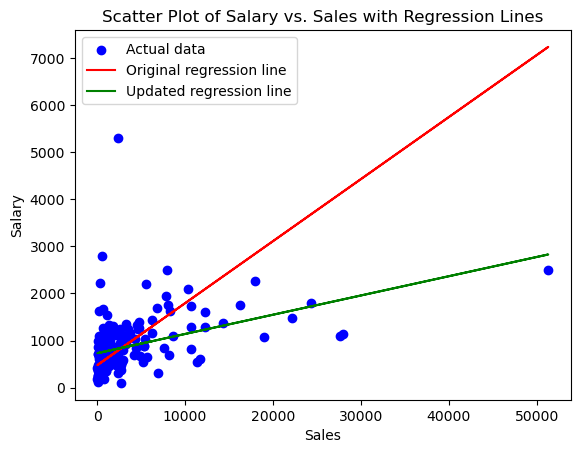

```python
plt.scatter(df['sales'], df['salary'], label='Actual data', color='blue')

# Plot the original regression line
plt.plot(df['sales'], df['prediction1'], label='Original regression line', color='red')

# Plot the updated regression line
plt.plot(df['sales'], df['prediction2'], label='Updated regression line', color='green')

# Add labels and title
plt.xlabel('Sales')
plt.ylabel('Salary')
plt.title('Scatter Plot of Salary vs. Sales with Regression Lines')
plt.legend()

# Show the plot
plt.show()
```

## iii) We can see here that the updated regression line better fits the data than the original because we removed the 15000 outlier from the data.

iv. A colleague presented a histogram displaying the distribution of salary and argued that no one could draw any conclusions from a regression using this variable. He correctly points out that regression lines fit through data better when the data is spread across the range of the variable’s possible values. Your colleague wants to use the natural **log of salary** and the natural **log ofbsales** in the model as this function can help to spread out the values of salary and sales. Create the natural logarithm of salary, lnsalary, and the natural logarithm of sales, lnsales. Show the histograms of salary, lnsalary, sales, and lnsales. Discuss whether you think your colleague’s method of spreading the data worked. Estimate the following model:

$lnsalaryi=\gamma_0+\gamma_1lnsalesi+vi$

Then show the regression plot for this new model

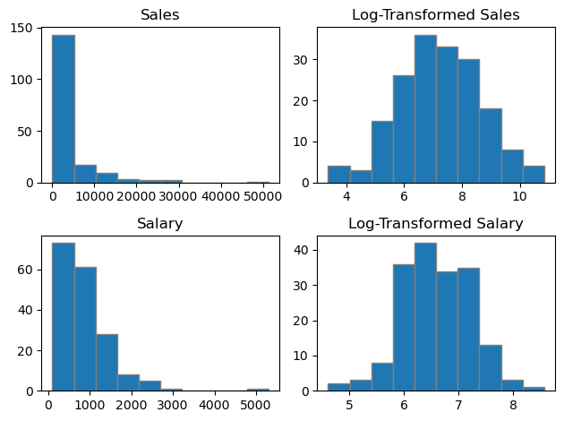

```python
# Create the variables lnsales and lnsalary in the dataset
df["lnsales"]=np.log(df.sales)
df["lnsalary"]=np.log(df.salary)

# Fora graph like this you need to create the grid space for plots
#define grid of plots
fig, axs = plt.subplots(nrows=2, ncols=2)

#create histograms
# Each of the 4 histograms will for in one position of the grid, for example the first one
axs[0,0].hist(df["sales"], edgecolor='gray');
# Now you do the rest try your best to do this on your own it should be pretty easy with the first one.
axs[0,1].hist(df["lnsales"], edgecolor='gray')
axs[1,0].hist(df["salary"], edgecolor='gray')
axs[1,1].hist(df["lnsalary"], edgecolor='gray')


#add title to each histogram
axs[0,0].set_title('Sales');
axs[0,1].set_title('Log-Transformed Sales');

#add title to each histogram
axs[0,0].set_title('Sales')
axs[0,1].set_title('Log-Transformed Sales')
axs[1,0].set_title('Salary');
axs[1,1].set_title('Log-Transformed Salary');
plt.tight_layout()
plt.show()
```

```python
model3 = smf.ols(formula = 'lnsalary ~ lnsales', data = df).fit()
model3.summary()
```

OLS Regression Results

| Dep. Variable: | lnsalary | R-squared: | 0.286 |
| --- | --- | --- | --- |
| Model: | OLS | Adj. R-squared: | 0.282 |
| Method: | Least Squares | F-statistic: | 70.07 |
| Date: | Thu, 24 Oct 2024 | Prob (F-statistic): | 1.77e-14 |
| Time: | 10:44:55 | Log-Likelihood: | -134.22 |
| No. Observations: | 177 | AIC: | 272.4 |
| Df Residuals: | 175 | BIC: | 278.8 |
| Df Model: | 1 |  |  |
| Covariance Type: | nonrobust |  |  |

|  | coef | std err | t | P>\|t\| | [0.025 | 0.975] |
| --- | --- | --- | --- | --- | --- | --- |
| Intercept | 4.9319 | 0.202 | 24.472 | 0.000 | 4.534 | 5.330 |
| lnsales | 0.2289 | 0.027 | 8.371 | 0.000 | 0.175 | 0.283 |

| Omnibus: | 12.014 | Durbin-Watson: | 2.096 |
| --- | --- | --- | --- |
| Prob(Omnibus): | 0.002 | Jarque-Bera (JB): | 30.645 |
| Skew: | 0.068 | Prob(JB): | 2.22e-07 |
| Kurtosis: | 5.034 | Cond. No. | 38.7 |

Notes:  
[1] Standard Errors assume that the covariance matrix of the errors is correctly specified.

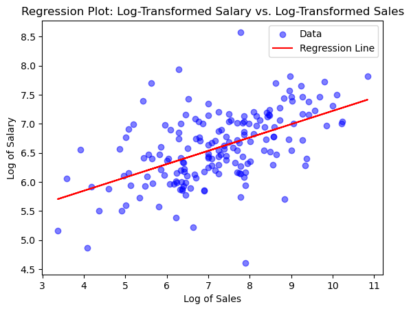

```python
X_log = df['lnsales']
y_log = df['lnsalary']

# do the regression plot here.
plt.scatter(df['lnsales'], df['lnsalary'], label='Data', color='blue', alpha=0.5)
plt.plot(df['lnsales'], model3.predict(X_log), label='Regression Line', color='red')
plt.xlabel('Log of Sales')
plt.ylabel('Log of Salary')
plt.title('Regression Plot: Log-Transformed Salary vs. Log-Transformed Sales')
plt.legend()

# Show the plot
plt.show()
```

# Question 2

Use the dataset ATTEND for this exercise, and the handouts to work on these questions. Wooldridge data sets here: http://fmwww.bc.edu/ec-p/data/wooldridge/datasets.list.html

i. Generate a table that shows the minimum, maximum, and average values for the following variables in the attend dataset:  
Percent classes attended  
Cumulative GPA prior to term  
ACT score  
Using two different methods. Round off all calculations to 3 decimal points. (Refer to week 3 module)

```python
# Load dataset attend from wooldridge, call it attend.
attend = woo.dataWoo('attend')
# Method 1: Use .agg() to calculate, call it tablestats.
tablestats = attend[['atndrte', 'priGPA', 'ACT']].agg(['min', 'max', 'mean']).round(3)
print(f'{tablestats}')
```

```
      atndrte  priGPA    ACT
min      6.25   0.857  13.00
max    100.00   3.930  32.00
mean    81.71   2.587  22.51
```

```python
# Method 2: Use .describe() to calculate.
tablestats2 = attend[['atndrte', 'priGPA', 'ACT']].describe().round(3)
tablestats2 = tablestats2.loc[['min', 'max', 'mean']]
print(f'{tablestats2}')
```

```
      atndrte  priGPA    ACT
min      6.25   0.857  13.00
max    100.00   3.930  32.00
mean    81.71   2.587  22.51
```

ii. Estimate the following model:

$$atndrte = \beta_0 + \beta_1 priGPA + \beta_2 ACT + u$$

Show results in an stargazer table. (Refer to output presentation handout)

```python
# Estimate log-level model, call it mc4.
mc4 = smf.ols('atndrte ~ priGPA + ACT', data=attend).fit()
mc4.summary()
# Fit your regression using .fit().

# Print results using summary:
stargazer = Stargazer([mc4])
stargazer.title("Regression Results for Attendance Rate Model")
html_output = stargazer.render_html()
display(HTML(html_output))
```

Regression Results for Attendance Rate Model

|  | *Dependent variable: atndrte* |
| --- | --- |
|  | (1) |
| ACT | -1.717*** |
|  | (0.169) |
| Intercept | 75.700*** |
|  | (3.884) |
| priGPA | 17.261*** |
|  | (1.083) |
| Observations | 680 |
| R<sup>2</sup> | 0.291 |
| Adjusted R<sup>2</sup> | 0.288 |
| Residual Std. Error | 14.379 (df=677) |
| F Statistic | 138.651*** (df=2; 677) |
| Note: | *p<0.1; **p<0.05; ***p<0.01 |

iii. Calculate and print the average of predicted value of percent classes attended ( $\hat{atndrte}$ ) and the predicted value. Round to 5 decimal points and compare results. (Refer to week 5 module)

> Note that these two are different coding-wise. The first method is the mean of the prediction, and the second is the prediction of the mean

```python
# Print the mean of the prediction
predic = mc4.predict()
predic_mean = predic.mean()
print(f'{predic_mean:.5f}')
# Find the prediction of the mean
mean_priGPA = attend['priGPA'].mean()
mean_ACT = attend['ACT'].mean()
mean_input = pd.DataFrame({'priGPA': [mean_priGPA], 'ACT': [mean_ACT]})

# Predict the value of atndrte using the mean input values
prediction_of_mean = mc4.predict(mean_input)[0]
# Print the prediction of the mean
print(f'{prediction_of_mean:.5f}')
```

```
81.70956
81.70956
```

## iii) The average of the predicted values of percent classes attended is the same as the predicted values.

iv. What is the predicted `atndrte` if `priGPA`= 3.65 and `ACT`= 20? What is the predicted difference in attendance rates between this and the the average $\hat{atndrte}$ above? (Refer to week 3 and 4 module)
In this case, do not use the `.predict()` function for your code. Instead, retrieve the coeffients and calculate the equation.
$$atndrte = \hat\beta_0 + \hat\beta_1 3.65 + \hat\beta_2 20 + u$$

```python
# Calculate the mean of the prediction, call this yhat1.
yhat1 = predic_mean

# Calculate predicted atndrte for 3.65 GPA and 20 ACT using the above equation, call this yhat2.
# Step 2: Manually calculate the predicted atndrte for priGPA = 3.65 and ACT = 20
beta_0 = mc4.params['Intercept']
beta_1 = mc4.params['priGPA']
beta_2 = mc4.params['ACT']
priGPA_value = 3.65
ACT_value = 20
yhat2 = beta_0 + beta_1 * priGPA_value + beta_2 * ACT_value

yhat2 = beta_0 + beta_1 * priGPA_value + beta_2 * ACT_value
# Print yhat2 and round to 3 decimal places, call this yhat.
print(f'{yhat2}')
yhat = yhat2.round(3)
print(f'{yhat}')
# Print the difference between yhat2 and yhat1, call this difference.
difference = yhat2 - yhat1
print(f'{difference:.3f}')
```

```
104.37050350693792
104.371
22.661
```

v. Run two more models: one only for freshmen and another only for sophomores. Save the results in objects `mfre` and `msoph` respectively  
*Hint: the data argument now has a restriction*  
Freshmen : `attend['frosh']==1`  
Sophomores : `attend['soph']==1`

```python
# compute OLS only for freshmen
mfre = smf.ols('atndrte ~ priGPA + ACT', data=attend[attend['frosh'] == 1]).fit()
display(mfre.summary())
# Step 2: OLS Regression for Sophomores
msoph = smf.ols('atndrte ~ priGPA + ACT', data=attend[attend['soph'] == 1]).fit()
display(msoph.summary())
# compute OLS only for sophomores
```

OLS Regression Results

| Dep. Variable: | atndrte | R-squared: | 0.286 |
| --- | --- | --- | --- |
| Model: | OLS | Adj. R-squared: | 0.277 |
| Method: | Least Squares | F-statistic: | 31.11 |
| Date: | Fri, 25 Oct 2024 | Prob (F-statistic): | 4.39e-12 |
| Time: | 16:49:04 | Log-Likelihood: | -639.98 |
| No. Observations: | 158 | AIC: | 1286. |
| Df Residuals: | 155 | BIC: | 1295. |
| Df Model: | 2 |  |  |
| Covariance Type: | nonrobust |  |  |

|  | coef | std err | t | P>\|t\| | [0.025 | 0.975] |
| --- | --- | --- | --- | --- | --- | --- |
| Intercept | 76.5071 | 8.679 | 8.815 | 0.000 | 59.363 | 93.652 |
| priGPA | 16.0619 | 2.362 | 6.800 | 0.000 | 11.396 | 20.728 |
| ACT | -1.4869 | 0.331 | -4.497 | 0.000 | -2.140 | -0.834 |

| Omnibus: | 34.591 | Durbin-Watson: | 1.929 |
| --- | --- | --- | --- |
| Prob(Omnibus): | 0.000 | Jarque-Bera (JB): | 55.001 |
| Skew: | -1.116 | Prob(JB): | 1.14e-12 |
| Kurtosis: | 4.837 | Cond. No. | 173. |

Notes:  
[1] Standard Errors assume that the covariance matrix of the errors is correctly specified.

OLS Regression Results

| Dep. Variable: | atndrte | R-squared: | 0.320 |
| --- | --- | --- | --- |
| Model: | OLS | Adj. R-squared: | 0.316 |
| Method: | Least Squares | F-statistic: | 91.51 |
| Date: | Fri, 25 Oct 2024 | Prob (F-statistic): | 2.68e-33 |
| Time: | 16:49:04 | Log-Likelihood: | -1593.6 |
| No. Observations: | 392 | AIC: | 3193. |
| Df Residuals: | 389 | BIC: | 3205. |
| Df Model: | 2 |  |  |
| Covariance Type: | nonrobust |  |  |

|  | coef | std err | t | P>\|t\| | [0.025 | 0.975] |
| --- | --- | --- | --- | --- | --- | --- |
| Intercept | 74.8871 | 5.113 | 14.646 | 0.000 | 64.834 | 84.940 |
| priGPA | 18.8691 | 1.440 | 13.101 | 0.000 | 16.037 | 21.701 |
| ACT | -1.8983 | 0.227 | -8.378 | 0.000 | -2.344 | -1.453 |

| Omnibus: | 67.032 | Durbin-Watson: | 2.014 |
| --- | --- | --- | --- |
| Prob(Omnibus): | 0.000 | Jarque-Bera (JB): | 118.063 |
| Skew: | -0.981 | Prob(JB): | 2.31e-26 |
| Kurtosis: | 4.838 | Cond. No. | 167. |

Notes:  
[1] Standard Errors assume that the covariance matrix of the errors is correctly specified.

vi. Show your results in a table:

Create one table comparing the parameters from the three models and another table comparing $R^2$ and the number of observations. Label the results with all students "All", data with just freshmen "Freshmen", and data with just sophomores "Sophomore". Round all values to 4 decimal places. (Refer to week 3 module)

The table below compares $\beta's$

```python
all_params = mc4.params
fre_params = mfre.params
soph_params = msoph.params
table = pd.DataFrame({
    'All': all_params,
    'Freshmen': fre_params,
    'Sophomore': soph_params
})

table_formatted = table.style.format("{:,.4f}")

r_squared = [mc4.rsquared, mfre.rsquared, msoph.rsquared]
n_obs = [int(mc4.nobs), int(mfre.nobs), int(msoph.nobs)]

comparison = pd.DataFrame({
    'R-squared': r_squared,
    'Number of Observations': n_obs
}, index=['All', 'Freshmen', 'Sophomore'])

comparison_formatted = comparison.style.format("{:,.4f}")


display(table_formatted)
# Table formatting is given to you
#table.style.format('{:,.3f}'.format)
```

|  | All | Freshmen | Sophomore |
| --- | --- | --- | --- |
| Intercept | 75.7004 | 76.5071 | 74.8871 |
| priGPA | 17.2606 | 16.0619 | 18.8691 |
| ACT | -1.7166 | -1.4869 | -1.8983 |

[output not shown]

The table below compares the $R^2$ and observations for the models estimated. $\textbf{HINT:}$ If you are stuck, look up how to use the index options.

```python
display(comparison_formatted)
```

|  | R-squared | Number of Observations |
| --- | --- | --- |
| All | 0.2906 | 680.0000 |
| Freshmen | 0.2864 | 158.0000 |
| Sophomore | 0.3200 | 392.0000 |

vii. Calculate the correlation between the residuals and the `priGPA` for the first model. This is similar to how we showed that mean of residuals is equal to zero (Refer to week 3 and module).

```python
# Calculate the residuals from the first model, call this u_hat.
u_hat = mc4.resid
# Calculate the correlation between the residuals and priGPA, call this corrx_u_hat. Round to 3 decimal places.
corr_matrix = attend['priGPA'].corr(u_hat)
corrx_u_hat = round(corr_matrix, 3)
# Remember this accesses the first element of the correlation matrix

# Printing is given to you:
print(f'Corr GPA and residuals:  \n', abs(corrx_u_hat))
# this number approximates to zero from the left hand side
# so we use the absolute value so that it doesn't have a negative sign
```

```
Corr GPA and residuals:
 0.0
```

vi. Present all results form the three models in an stargazer table Change the order of the covariates and add name to the columns

```python
# print results using summary:
stargazer1 = Stargazer([mc4, mfre, msoph])
stargazer1.title("Comparison of Attendance Models")
stargazer1.custom_columns(["All Students", "Freshmen", "Sophomores"], [1, 1, 1])
html_output1 = stargazer1.render_html()
display(HTML(html_output1))
```

Comparison of Attendance Models

|  | *Dependent variable: atndrte* |  |  |
| --- | --- | --- | --- |
|  | All Students | Freshmen | Sophomores |
|  | (1) | (2) | (3) |
| ACT | -1.717*** | -1.487*** | -1.898*** |
|  | (0.169) | (0.331) | (0.227) |
| Intercept | 75.700*** | 76.507*** | 74.887*** |
|  | (3.884) | (8.679) | (5.113) |
| priGPA | 17.261*** | 16.062*** | 18.869*** |
|  | (1.083) | (2.362) | (1.440) |
| Observations | 680 | 158 | 392 |
| R<sup>2</sup> | 0.291 | 0.286 | 0.320 |
| Adjusted R<sup>2</sup> | 0.288 | 0.277 | 0.316 |
| Residual Std. Error | 14.379 (df=677) | 14.029 (df=155) | 14.157 (df=389) |
| F Statistic | 138.651*** (df=2; 677) | 31.106*** (df=2; 155) | 91.510*** (df=2; 389) |
| Note: | *p<0.1; **p<0.05; ***p<0.01 |  |  |

# From Computer Exercise 10

Use the data in Wooldridge's HTV to answer this question. The data set includes information on wages, education, parents’ education, and several other variables for 1,230 working men in 1991.

i. Investigate some descriptive statistics

- What is the range of the `educ` variable in the sample?

```python
# Load the dataset, call it htv.
htv = woo.dataWoo('htv')
# Find some descriptive statistics of the education variable, use des.()
display(htv['educ'].describe())
desc_stats = htv['educ'].describe()
educ_range = desc_stats['max'] - desc_stats['min']
print(f'{educ_range}')



# Summary provides the mean and max of the variable - therefore the range
```

```
count    1230.000000
mean       13.037398
std         2.354346
min         6.000000
25%        12.000000
50%        12.000000
75%        15.000000
max        20.000000
Name: educ, dtype: float64
```

```
14.0
```

- What percentage of men completed twelveth grade but no higher grade?

  > Hint: use a logical expression and calculate the mean
- Do the men or their parents have, on average, higher levels of education?

```python
# Calculate the percentage of men that did not complete more than high school, print this as Percentage of men with HS.
percentage_hs_only = (htv['educ'] == 12).mean() * 100
print(f'{percentage_hs_only:.3f}')
```

```
41.626
```

```python
# Create a table with average education for the men, their mothers, and their fathers, call this table p.
average_educ_men = htv['educ'].mean()
average_educ_mother = htv['motheduc'].mean()
average_educ_father = htv['fatheduc'].mean()

p = {
    'Men': average_educ_men,
    'Mothers': average_educ_mother,
    'Fathers': average_educ_father
}
# The given code below will print the table.
ptable = pd.DataFrame(round(pd.Series(p), 3), columns=["Averages"])
print(ptable)
```

```
         Averages
Men        13.037
Mothers    12.178
Fathers    12.447
```

## i) The men on average have more years of education

ii. Estimate the regression model
$$educ = \beta_0 + \beta_1motheduc + \beta_2fatheduc + u$$
by OLS and report the results in the usual form.

How much sample variation in `educ` is explained by parents’ education? Think about the interpretation of the coefficient on `motheduc`.

```python
# Print the regression results
model1 = smf.ols('educ ~ motheduc + fatheduc', data=htv).fit()
model1.summary()
```

OLS Regression Results

| Dep. Variable: | educ | R-squared: | 0.249 |
| --- | --- | --- | --- |
| Model: | OLS | Adj. R-squared: | 0.248 |
| Method: | Least Squares | F-statistic: | 203.7 |
| Date: | Fri, 25 Oct 2024 | Prob (F-statistic): | 4.13e-77 |
| Time: | 17:35:11 | Log-Likelihood: | -2621.7 |
| No. Observations: | 1230 | AIC: | 5249. |
| Df Residuals: | 1227 | BIC: | 5265. |
| Df Model: | 2 |  |  |
| Covariance Type: | nonrobust |  |  |

|  | coef | std err | t | P>\|t\| | [0.025 | 0.975] |
| --- | --- | --- | --- | --- | --- | --- |
| Intercept | 6.9644 | 0.320 | 21.776 | 0.000 | 6.337 | 7.592 |
| motheduc | 0.3042 | 0.032 | 9.528 | 0.000 | 0.242 | 0.367 |
| fatheduc | 0.1903 | 0.022 | 8.539 | 0.000 | 0.147 | 0.234 |

| Omnibus: | 60.519 | Durbin-Watson: | 1.748 |
| --- | --- | --- | --- |
| Prob(Omnibus): | 0.000 | Jarque-Bera (JB): | 82.103 |
| Skew: | 0.455 | Prob(JB): | 1.48e-18 |
| Kurtosis: | 3.879 | Cond. No. | 98.0 |

Notes:  
[1] Standard Errors assume that the covariance matrix of the errors is correctly specified.

## ii) About 25% of the variation in educ is explained by the parent's education. For mothereduc, for each additional year of education that the mother gets, the son is, on average, expected to gain about 0.3 more years of education.

iii. Add the variable `abil` (a measure of cognitive ability) to the regression from part (ii), and report the results in equation form. Does “ability” help to explain variations in education, even after controlling for parents’ education? Explain.

```python
# Print the new ols regressions results
model2 = smf.ols('educ ~ motheduc + fatheduc + abil', data=htv).fit()
model2.summary()
```

OLS Regression Results

| Dep. Variable: | educ | R-squared: | 0.428 |
| --- | --- | --- | --- |
| Model: | OLS | Adj. R-squared: | 0.426 |
| Method: | Least Squares | F-statistic: | 305.2 |
| Date: | Fri, 25 Oct 2024 | Prob (F-statistic): | 5.95e-148 |
| Time: | 17:39:49 | Log-Likelihood: | -2455.0 |
| No. Observations: | 1230 | AIC: | 4918. |
| Df Residuals: | 1226 | BIC: | 4938. |
| Df Model: | 3 |  |  |
| Covariance Type: | nonrobust |  |  |

|  | coef | std err | t | P>\|t\| | [0.025 | 0.975] |
| --- | --- | --- | --- | --- | --- | --- |
| Intercept | 8.4487 | 0.290 | 29.180 | 0.000 | 7.881 | 9.017 |
| motheduc | 0.1891 | 0.029 | 6.635 | 0.000 | 0.133 | 0.245 |
| fatheduc | 0.1111 | 0.020 | 5.586 | 0.000 | 0.072 | 0.150 |
| abil | 0.5025 | 0.026 | 19.538 | 0.000 | 0.452 | 0.553 |

| Omnibus: | 52.055 | Durbin-Watson: | 1.821 |
| --- | --- | --- | --- |
| Prob(Omnibus): | 0.000 | Jarque-Bera (JB): | 61.086 |
| Skew: | 0.465 | Prob(JB): | 5.44e-14 |
| Kurtosis: | 3.570 | Cond. No. | 102. |

Notes:  
[1] Standard Errors assume that the covariance matrix of the errors is correctly specified.

```python
intercept = model2.params['Intercept']
beta_motheduc = model2.params['motheduc']
beta_fatheduc = model2.params['fatheduc']
beta_abil = model2.params['abil']

print(f" The estimated regression equation is: {intercept:.3f} + {beta_motheduc:.3f}*motheduc + {beta_fatheduc:.3f}*fatheduc + {beta_abil:.3f}*abil")
```

```
 The estimated regression equation is: 8.449 + 0.189*motheduc + 0.111*fatheduc + 0.502*abil
```

## iii) It does, as adding this new variable explains more variation for educ than the last model

iv. Now estimate an equation where `abil` appears in quadratic form

```python
# Add in abil squared using numpy and fit the model, call this m3.
htv['abil_squared'] = np.power(htv['abil'], 2)
m3 = smf.ols('educ ~ motheduc + fatheduc + abil + abil_squared', data=htv).fit()

# Print the regression results using .summary()
m3.summary()
```

OLS Regression Results

| Dep. Variable: | educ | R-squared: | 0.444 |
| --- | --- | --- | --- |
| Model: | OLS | Adj. R-squared: | 0.443 |
| Method: | Least Squares | F-statistic: | 244.9 |
| Date: | Fri, 25 Oct 2024 | Prob (F-statistic): | 1.34e-154 |
| Time: | 17:51:26 | Log-Likelihood: | -2436.6 |
| No. Observations: | 1230 | AIC: | 4883. |
| Df Residuals: | 1225 | BIC: | 4909. |
| Df Model: | 4 |  |  |
| Covariance Type: | nonrobust |  |  |

|  | coef | std err | t | P>\|t\| | [0.025 | 0.975] |
| --- | --- | --- | --- | --- | --- | --- |
| Intercept | 8.2402 | 0.287 | 28.671 | 0.000 | 7.676 | 8.804 |
| motheduc | 0.1901 | 0.028 | 6.767 | 0.000 | 0.135 | 0.245 |
| fatheduc | 0.1089 | 0.020 | 5.558 | 0.000 | 0.070 | 0.147 |
| abil | 0.4015 | 0.030 | 13.255 | 0.000 | 0.342 | 0.461 |
| abil_squared | 0.0506 | 0.008 | 6.093 | 0.000 | 0.034 | 0.067 |

| Omnibus: | 45.933 | Durbin-Watson: | 1.820 |
| --- | --- | --- | --- |
| Prob(Omnibus): | 0.000 | Jarque-Bera (JB): | 56.769 |
| Skew: | 0.404 | Prob(JB): | 4.71e-13 |
| Kurtosis: | 3.674 | Cond. No. | 115. |

Notes:  
[1] Standard Errors assume that the covariance matrix of the errors is correctly specified.

v. Use the estimates in part (iv) to graph the relationship between the predicted `education` and `abil`. Set `motheduc` and `fatheduc` at their average values in the sample, 12.18 and 12.45, respectively. See handout for more. (Refer to week 4 module)

```python
# look at the coeficients
intercept = m3.params['Intercept']
beta_motheduc = m3.params['motheduc']
beta_fatheduc = m3.params['fatheduc']
beta_abil = m3.params['abil']
beta_abil_squared = m3.params['abil_squared']
avg_motheduc = 12.18
avg_fatheduc = 12.45
```

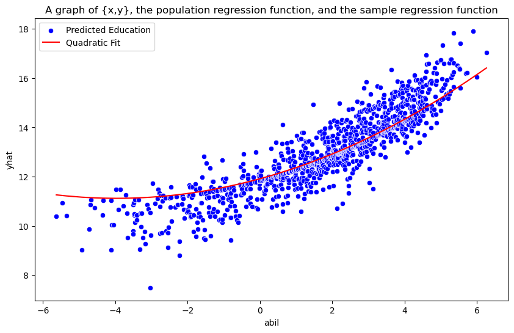

```python
#Set up the objects for our graph:
#Predicted fitted values
htv['yhat'] = m3.fittedvalues

#Residuals
htv['resid'] = m3.resid

# Create a variable 'yaveduc' in your data set that is the estimated y for the average values for education but that still changes with ability.
# Hint retrieve all the parameters and set the linear model equation and construct the regrssion in a similar fashion as (iv)
htv['yaveduc'] = (intercept + beta_motheduc * avg_motheduc + beta_fatheduc * avg_fatheduc +beta_abil * htv['abil'] +beta_abil_squared * htv['abil']**2)

# You need to sort the values by abil so that the line plots nicely. Try not doing it and see what happens
htv.sort_values(by=['abil'], inplace=True)

# Create the scatter of the abil vs predicted education function, set the title as "log(Salary) vs log(Sales)"
# Hint see how we used sns.regplot in the handout
plt.figure(figsize=(10, 6))
sns.scatterplot(x='abil', y='yhat', data=htv, label='Predicted Education', color='blue')
# Add the line that shows the quadratic relation between this two.
# Hint see how we used plt.plot in the handout
plt.plot(htv['abil'], htv['yaveduc'], color='red', label='Quadratic Fit')

# This code is given to label and produce the graph:
plt.title("A graph of {x,y}, the population regression function, and the sample regression function" )
plt.legend(loc='upper left')
plt.show()
```

ECON320 Python Programming Laboratory

Professor *Paloma Lopez de mesa Moyano*

*paloma.moyano@emory.edu*

Department of Economics

Emory University

```python
# convert file into HTML
```